# Problem Set 1 (Answers)

Ryan Safner

ECON 480 - Fall 2019

*Due by Thursday, September 19, 2019*

- `Download as PDF`
- `04-r-practice-answers.Rmd`

# Instructions

For this problem set, you may type up your answers to each question (save plots as images and include them with your answers) and also turn in a (commented!) *.R* file of commands for each relevant question. You may email or turn in a paper copy. It is not relevant for this particular problem set, but in the future, I will allow handwritten answers for math/theory questions.

Alternatively, you may download the `.Rmd` file, do the homework in markdown, and email to me a single `knit`ted `html` or `pdf` file (and be sure that it shows all of your code).

To minimize confusion, I suggest creating a new `R Project` (e.g. `hw1`) and storing any data and plots in that folder on your computer. See my [example workflow](https://github.com/ryansafner/workflow).

You may work together (and I highly encourage that) but you must turn in your own answers. I grade homeworks 70% for completion, and for the remaining 30%, pick one question to grade for accuracy - so it is best that you try every problem, even if you are unsure how to complete it accurately.

# The Popularity of Baby Names

**Install and load the package `babynames`. Get help for `?babynames` to see what the data includes.**

```r
library(tidyverse)
# install for first use
# install.packages("babynames")

# load package
library(babynames)

# explore help
# ?babynames
```

## 1.

### a.

**What are the top 5 boys names for 2017, and what *percent* of overall names is each?**

```r
# save as a new tibble
top_5_boys_2017 <- babynames %>% # take data
  filter(sex=="M", # filter by males
         year==2017) %>% # and for 2007
  arrange(desc(n)) %>% # arrange in largest-to-smallest order of n (number)
  slice(1:5) %>% # optional, look only at first 5 rows
  mutate(percent = round(prop*100, 2)) # also optional, make a percent variable rounded to 2 decimals

# look at our new tibble
top_5_boys_2017
```

| year | sex | name | n | prop | percent |
| --- | --- | --- | --- | --- | --- |
| 2017 | M | Liam | 18728 | 0.00953909 | 0.95 |
| 2017 | M | Noah | 18326 | 0.00933433 | 0.93 |
| 2017 | M | William | 14904 | 0.00759134 | 0.76 |
| 2017 | M | James | 14232 | 0.00724906 | 0.72 |
| 2017 | M | Logan | 13974 | 0.00711764 | 0.71 |

The top 5 names are

1. Liam (0.95%)
2. Noah (0.93%)
3. William (0.76%)
4. James (0.72%)
5. Logan (0.71%)

### b.

**What are the top 5 *girls* names, and what *percent* of overall names is each?**

```r
# save as a new tibble
top_5_girls_2017 <- babynames %>% # take data
  filter(sex=="F", # filter by females
         year==2017) %>% # and for 2007
  arrange(desc(n)) %>% # arrange in largest-to-smallest order of n (number)
  slice(1:5) %>% # optional, look only at first 5 rows
  mutate(percent = round(prop*100, 2)) # also optional, make a percent variable rounded to 2 decimals

# look at our new tibble
top_5_girls_2017
```

| year | sex | name | n | prop | percent |
| --- | --- | --- | --- | --- | --- |
| 2017 | F | Emma | 19738 | 0.01052750 | 1.05 |
| 2017 | F | Olivia | 18632 | 0.00993760 | 0.99 |
| 2017 | F | Ava | 15902 | 0.00848152 | 0.85 |
| 2017 | F | Isabella | 15100 | 0.00805377 | 0.81 |
| 2017 | F | Sophia | 14831 | 0.00791029 | 0.79 |

The top 5 names are

1. Emma (1.05%)
2. Olivia (0.99%)
3. Ava (0.85%)
4. Isabella (0.81%)
5. Sophia (0.79%)

## 2.

**Make two barplots, of these top 5 names, one for each sex. Map `aes`thetics `x` to `name` and `y` to `prop`[^1] and use `geom_col` (since you are declaring a specific `y`, otherwise you could just use `geom_bar()` and just an `x`.)**

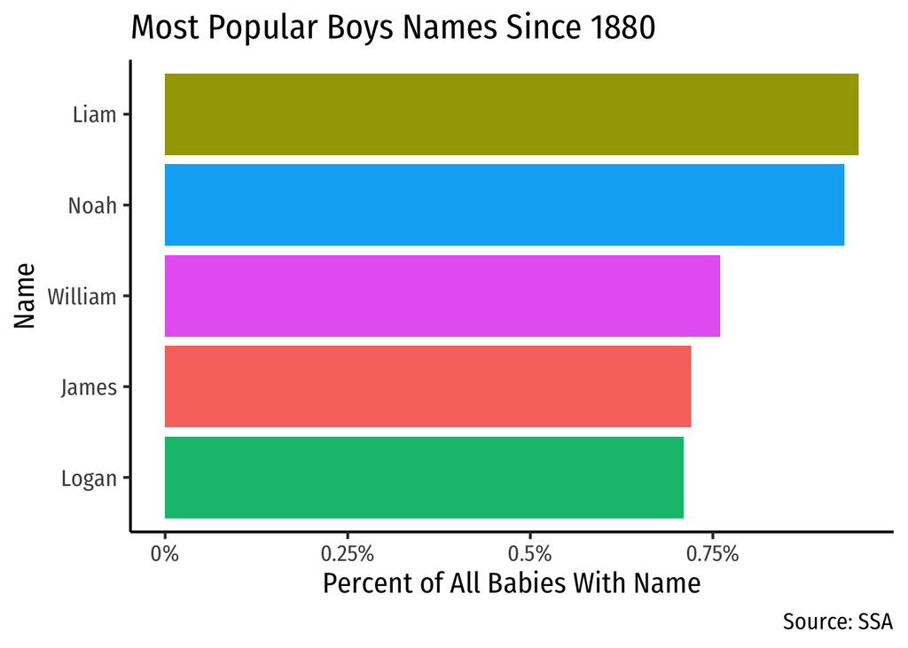

```r
ggplot(data = top_5_boys_2017)+
  aes(x = reorder(name, n), #note this reorders the x variable from small to large n
      y = percent, # you can use prop if you didn't make a percent variable
      fill = name)+ # optional color!
  geom_col()+

  # now I'm just making it pretty
  scale_y_continuous(labels=function(x)paste(x,"%",sep=""))+ # optional, add percent signs
      labs(x = "Name",
         y = "Percent of All Babies With Name",
         title = "Most Popular Boys Names Since 1880",
         fill = "Boy's Name",
         caption = "Source: SSA")+
    theme_classic(base_family = "Fira Sans Condensed", base_size=16)+
  coord_flip()+ # rotate axes!
  theme(legend.position = "") # hide legend
```

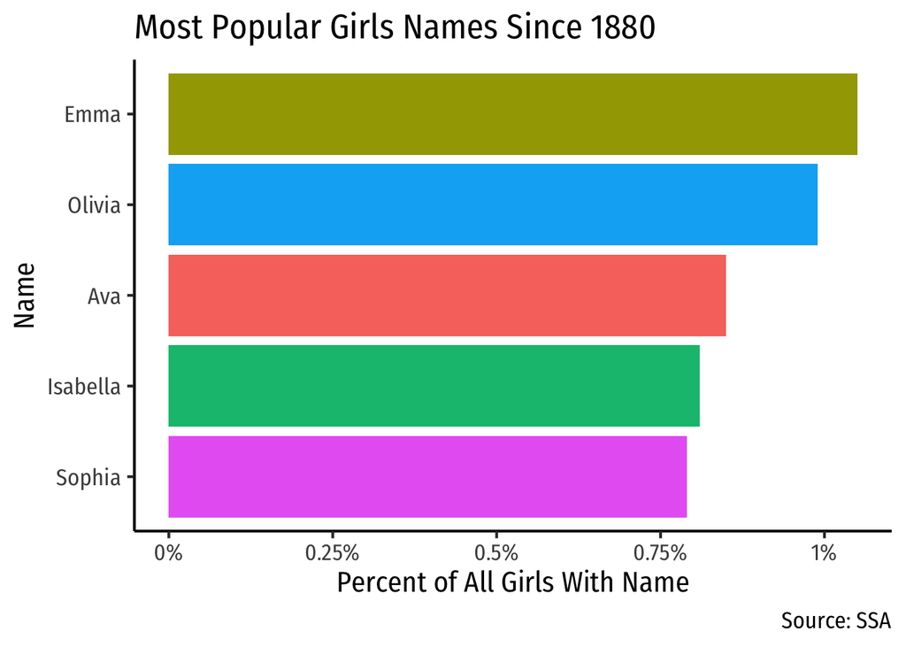

```r
ggplot(data = top_5_girls_2017)+
  aes(x = reorder(name, n), #note this reorders the x variable from small to large n
      y = percent, # you can use prop if you didn't make a percent variable
      fill = name)+ # optional color!
  geom_col()+
  # now I'm just making it pretty
  scale_y_continuous(labels=function(x)paste(x,"%",sep=""))+ # optional, add percent signs
      labs(x = "Name",
         y = "Percent of All Girls With Name",
         title = "Most Popular Girls Names Since 1880",
         fill = "Girl's Name",
         caption = "Source: SSA")+
    theme_classic(base_family = "Fira Sans Condensed", base_size=16)+
  coord_flip()+ # rotate axes!
  theme(legend.position = "") # hide legend
```

## 3.

**Find your name.[^2] `count` by `sex` how many babies since 1880 were named your name.[^3] Also add a variable for the percent of each sex.**

```r
babynames %>%
  filter(name == "Ryan") %>%
  count(sex, wt=n) %>%
  mutate(percent = round((n/sum(n)*100),2))
```

| sex | n | percent |
| --- | --- | --- |
| F | 22910 | 2.42 |
| M | 924877 | 97.58 |

## 4.

**Make a line graph of the number of babies with your name over time, `color`ed by `sex`.**

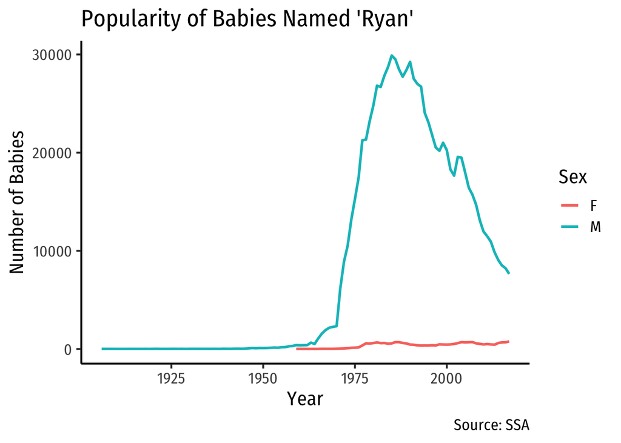

```r
babynames %>%
  filter(name == "Ryan") %>%
  ggplot(data = .)+
  aes(x = year,
      y = n,
      color = sex)+
  geom_line(size=1)+
  labs(x = "Year",
       y = "Number of Babies",
       title = "Popularity of Babies Named 'Ryan'",
       color = "Sex",
       caption = "Source: SSA")+
    theme_classic(base_family = "Fira Sans Condensed", base_size=16)
```

## 5.

### a.

**Make a table of the most common name for boys by year between 1980-2017.[^4]**

```r
babynames %>%
  group_by(year) %>%
  filter(sex == "M",
         year>1980) %>%
  arrange(desc(n))%>%
  slice(1)
```

| year | sex | name | n | prop |
| --- | --- | --- | --- | --- |
| 1981 | M | Michael | 68765 | 0.03692247 |
| 1982 | M | Michael | 68228 | 0.03615445 |
| 1983 | M | Michael | 67995 | 0.03649110 |
| 1984 | M | Michael | 67736 | 0.03610228 |
| 1985 | M | Michael | 64906 | 0.03373805 |
| 1986 | M | Michael | 64205 | 0.03342343 |
| 1987 | M | Michael | 63647 | 0.03264834 |
| 1988 | M | Michael | 64133 | 0.03204521 |
| 1989 | M | Michael | 65382 | 0.03120182 |
| 1990 | M | Michael | 65282 | 0.03034735 |

[output cut: 27 more lines]

### b.

**Now do the same for girls.**

```r
babynames %>%
  group_by(year) %>%
  filter(sex == "F",
         year>1980) %>%
  arrange(desc(n))%>%
  slice(1)
```

| year | sex | name | n | prop |
| --- | --- | --- | --- | --- |
| 1981 | F | Jennifer | 57049 | 0.03190242 |
| 1982 | F | Jennifer | 57115 | 0.03148593 |
| 1983 | F | Jennifer | 54342 | 0.03036962 |
| 1984 | F | Jennifer | 50561 | 0.02804442 |
| 1985 | F | Jessica | 48346 | 0.02619098 |
| 1986 | F | Jessica | 52674 | 0.02854888 |
| 1987 | F | Jessica | 55991 | 0.02988050 |
| 1988 | F | Jessica | 51538 | 0.02680669 |
| 1989 | F | Jessica | 47885 | 0.02403998 |
| 1990 | F | Jessica | 46475 | 0.02262700 |

[output cut: 27 more lines]

## 6. Now let’s graph the evolution of the most common names since 1880.

### a.

```r
babynames %>%
  group_by(name) %>%
  filter(sex=="M") %>%
  summarize(total=sum(n)) %>%
  arrange(desc(total)) %>%
  slice(1:5)
```

| name | total |
| --- | --- |
| James | 5150472 |
| John | 5115466 |
| Robert | 4814815 |
| Michael | 4350824 |
| William | 4102604 |

```r
top_boys_names<-c("James", "John", "Robert", "Michael", "William")
```

```r
babynames %>%
  group_by(name) %>%
  filter(sex=="F") %>%
  summarize(total=sum(n)) %>%
  arrange(desc(total)) %>%
  slice(1:5)
```

| name | total |
| --- | --- |
| Mary | 4123200 |
| Elizabeth | 1629679 |
| Patricia | 1571692 |
| Jennifer | 1466281 |
| Linda | 1452249 |

```r
top_girls_names<-c("Mary", "Elizabeth", "Patricia", "Jennifer", "Linda")
```

### b.

**Now make two `line`graphs of these 5 names over time, one for boys, and one for girls.**

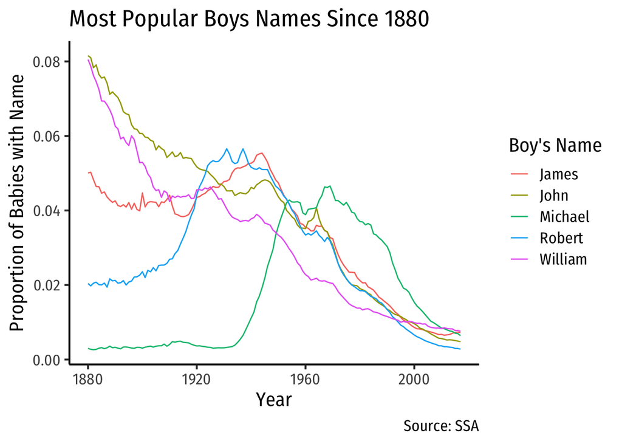

```r
babynames %>%
  group_by(year) %>%
  filter(sex == "M",
         name %in% top_boys_names) %>%
  ggplot(data = .,
         aes(x = year,
             y = prop,
             color = name))+
  geom_line()+
      labs(x = "Year",
         y = "Proportion of Babies with Name",
         title = "Most Popular Boys Names Since 1880",
         color = "Boy's Name",
         caption = "Source: SSA")+
    theme_classic(base_family = "Fira Sans Condensed", base_size=16)
```

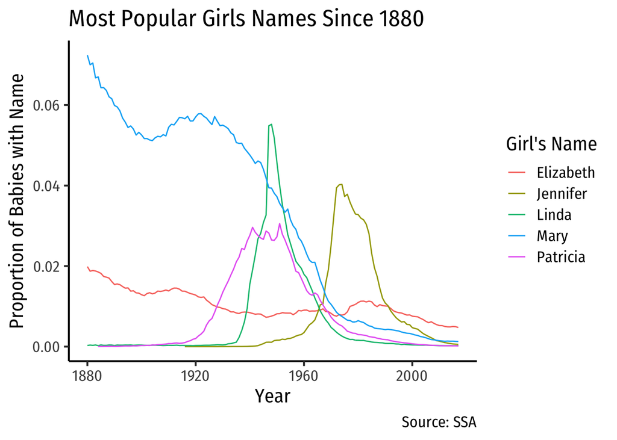

```r
babynames %>%
  group_by(year) %>%
  filter(sex == "F",
         name %in% top_girls_names) %>%
  ggplot(data = .,
         aes(x = year,
             y = prop,
             color = name))+
  geom_line()+
    labs(x = "Year",
         y = "Proportion of Babies with Name",
         title = "Most Popular Girls Names Since 1880",
         color = "Girl's Name",
         caption = "Source: SSA")+
    theme_classic(base_family = "Fira Sans Condensed", base_size=16)
```

## 7.

*Bonus (hard!)*: What are the 10 most common “gender-neutral” names?[^5]

```r
babynames %>%
  mutate(male = ifelse(sex == "M", n, 0),
         female = ifelse(sex == "F", n, 0)) %>%
  group_by(name) %>%
    summarize(Male = sum(male),
              Female = sum(female))%>%
  filter(Male!=0,
         Female!=0) %>%
  mutate(perc_male = (Male/(Male+Female)*100)) %>%
  arrange(perc_male) %>%
  filter(perc_male > 48,
         perc_male < 52) %>%
  mutate(total = Male+Female) %>%
  arrange(desc(total)) %>%
  slice(1:10)
```

| name | Male | Female | perc_male | total |
| --- | --- | --- | --- | --- |
| Kerry | 49596 | 48534 | 50.54112 | 98130 |
| Robbie | 20863 | 22264 | 48.37573 | 43127 |
| Justice | 17080 | 15782 | 51.97493 | 32862 |
| Blair | 14470 | 14195 | 50.47968 | 28665 |
| Kris | 13982 | 13490 | 50.89546 | 27472 |
| Elisha | 13330 | 13599 | 49.50054 | 26929 |
| Unknown | 9307 | 9416 | 49.70891 | 18723 |
| Mckinley | 9389 | 8955 | 51.18295 | 18344 |
| Baby | 6078 | 5871 | 50.86618 | 11949 |
| Santana | 4651 | 4952 | 48.43278 | 9603 |

# Political and Economic Freedom Around the World

**For the remaining questions, we’ll look at the relationship between Economic Freedom and Political Freedom in countries around the world today. Our data for economic freedom comes from the [Fraser Institute](https://www.fraserinstitute.org/economic-freedom/dataset?geozone=world&year=2016&page=dataset), and our data for political freedom comes from [Freedom House](https://freedomhouse.org/content/freedom-world-data-and-resources).**

## 8.

**Download these two datasets that I’ve cleaned up a bit:[^6]**

- [`econfreedom.csv`](http://metricsf19.classes.ryansafner.com/data/econfreedom.csv)
- [`freedomhouse2018.csv`](http://metricsf19.classes.ryansafner.com/data/freedomhouse2018.csv)

**Load them with `df<-read_csv("name_of_the_file.csv")` and save one as `econfreedom` and the other as `polfreedom`. Look at each `tibble` you’ve created.**

```r
# note these file paths will be different for you
polfreedom<-read.csv(here::here("./static/data/freedomhouse2018.csv"))
econfreedom<-read.csv(here::here("./static/data/econfreedom.csv"))

polfreedom
```

| Country.Territory | Status | PR.Rating | CL.Rating | A1 | A2 | A3 | A | B1 | B2 | B3 | B4 | B | C1 | C2 | C3 | C | Add.Q | PR | D1 | D2 | D3 | D4 | D | E1 | E2 | E3 | E | F1 | F2 | … |
| --- | --- | --- | --- | --- | --- | --- | --- | --- | --- | --- | --- | --- | --- | --- | --- | --- | --- | --- | --- | --- | --- | --- | --- | --- | --- | --- | --- | --- | --- | --- |
| Abkhazia | PF | 4 | 5 | 3 | 2 | 1 | 6 | 2 | 3 | 2 | 1 | 8 | 1 | 1 | 2 | 4 | 0 | 18 | 2 | 2 | 1 | 3 | 8 | 3 | 2 | 1 | 6 | 1 | 1 | … |
| Afghanistan | NF | 5 | 6 | 1 | 0 | 1 | 2 | 2 | 2 | 1 | 2 | 7 | 1 | 1 | 1 | 3 | 0 | 12 | 2 | 1 | 1 | 2 | 6 | 2 | 1 | 1 | 4 | 1 | 0 | … |
| Albania | PF | 3 | 3 | 3 | 3 | 2 | 8 | 3 | 4 | 3 | 3 | 13 | 3 | 2 | 2 | 7 | 0 | 28 | 2 | 4 | 3 | 4 | 13 | 4 | 3 | 2 | 9 | 2 | 2 | … |
| Algeria | NF | 6 | 5 | 1 | 1 | 1 | 3 | 1 | 1 | 1 | 1 | 4 | 1 | 1 | 1 | 3 | 0 | 10 | 1 | 1 | 2 | 3 | 7 | 2 | 1 | 2 | 5 | 1 | 1 | … |
| Andorra | F | 1 | 1 | 4 | 4 | 4 | 12 | 4 | 4 | 4 | 3 | 15 | 4 | 4 | 4 | 12 | 0 | 39 | 3 | 4 | 4 | 4 | 15 | 4 | 4 | 3 | 11 | 4 | 4 | … |
| Angola | NF | 6 | 6 | 0 | 2 | 1 | 3 | 2 | 1 | 1 | 2 | 6 | 1 | 0 | 0 | 1 | 0 | 10 | 1 | 2 | 2 | 2 | 7 | 1 | 1 | 1 | 3 | 1 | 1 | … |
| Antigua and Barbuda | F | 2 | 2 | 4 | 4 | 4 | 12 | 3 | 4 | 3 | 3 | 13 | 3 | 2 | 3 | 8 | 0 | 33 | 3 | 4 | 4 | 4 | 15 | 3 | 3 | 3 | 9 | 3 | 3 | … |
| Argentina | F | 2 | 2 | 4 | 4 | 3 | 11 | 4 | 3 | 4 | 3 | 14 | 3 | 2 | 3 | 8 | 0 | 33 | 3 | 4 | 4 | 4 | 15 | 4 | 4 | 3 | 11 | 2 | 3 | … |
| Armenia | PF | 5 | 4 | 1 | 1 | 2 | 4 | 2 | 2 | 1 | 2 | 7 | 1 | 1 | 2 | 4 | 0 | 15 | 2 | 2 | 2 | 3 | 9 | 2 | 2 | 2 | 6 | 1 | 1 | … |
| Australia | F | 1 | 1 | 4 | 4 | 4 | 12 | 4 | 4 | 4 | 4 | 16 | 4 | 4 | 4 | 12 | 0 | 40 | 4 | 4 | 4 | 4 | 16 | 4 | 4 | 4 | 12 | 4 | 4 | … |

[output cut: 199 more lines]

```r
econfreedom
```

| X | Country | ISO | ef | gdp | continent |
| --- | --- | --- | --- | --- | --- |
| 1 | Albania | ALB | 7.40 | 4543.0880 | Europe |
| 2 | Algeria | DZA | 5.15 | 4784.1943 | Africa |
| 3 | Angola | AGO | 5.08 | 4153.1463 | Africa |
| 4 | Argentina | ARG | 4.81 | 10501.6603 | Americas |
| 5 | Australia | AUS | 7.93 | 54688.4459 | Oceania |
| 6 | Austria | AUT | 7.56 | 47603.7968 | Europe |
| 7 | Bahrain | BHR | 7.60 | 22347.9708 | Asia |
| 8 | Bangladesh | BGD | 6.35 | 972.8807 | Asia |
| 9 | Belgium | BEL | 7.51 | 45181.4382 | Europe |
| 10 | Benin | BEN | 6.22 | 804.7240 | Africa |

[output cut: 102 more lines]

## 9.

**The `polfreedom` dataset is still a bit messy. Let’s overwrite it (or assign to something like `polfreedom2`) and select `Country.Territory` and `Total` (total freedom score) and rename `Country.Territory` to `Country`.**

```r
polfreedom<-polfreedom %>%
  select(Country.Territory, Total) %>%
  rename(Country=Country.Territory)
```

## 10.

**Now we can try to merge these two datasets into one. Since they both have `Country` as a variable, we can merge these tibbles using `left_join(econfreedom, polfreedom, by="Country")`[^7] and save this as a new tibble (something like `freedom`).**

```r
freedom<-left_join(econfreedom, polfreedom, by="Country")
```

## 11.

**Now make a scatterplot of Political Freedom (`total`)[^8] as `y` on Economic Freedom (`ef`) as `x` and `color` by `continent`.**

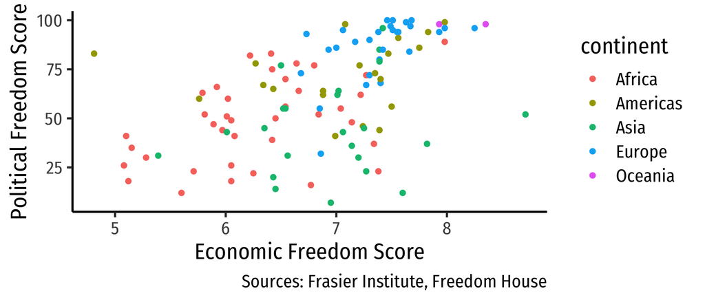

## 12.

**Let’s do this again, but highlight some key countries. Pick three countries, and make a new tibble from `freedom` that is only the observations of those countries. Additionally, *install* and *load* a packaged called `ggrepel`[^9] Next, redo your plot from question 11, but now add a layer: `geom_label_repel` and set its `data` to your three-country tibble, use same `aes`thetics as your overall plot, but be sure to add `label = ISO`, to use the ISO country code to label.[^10]**

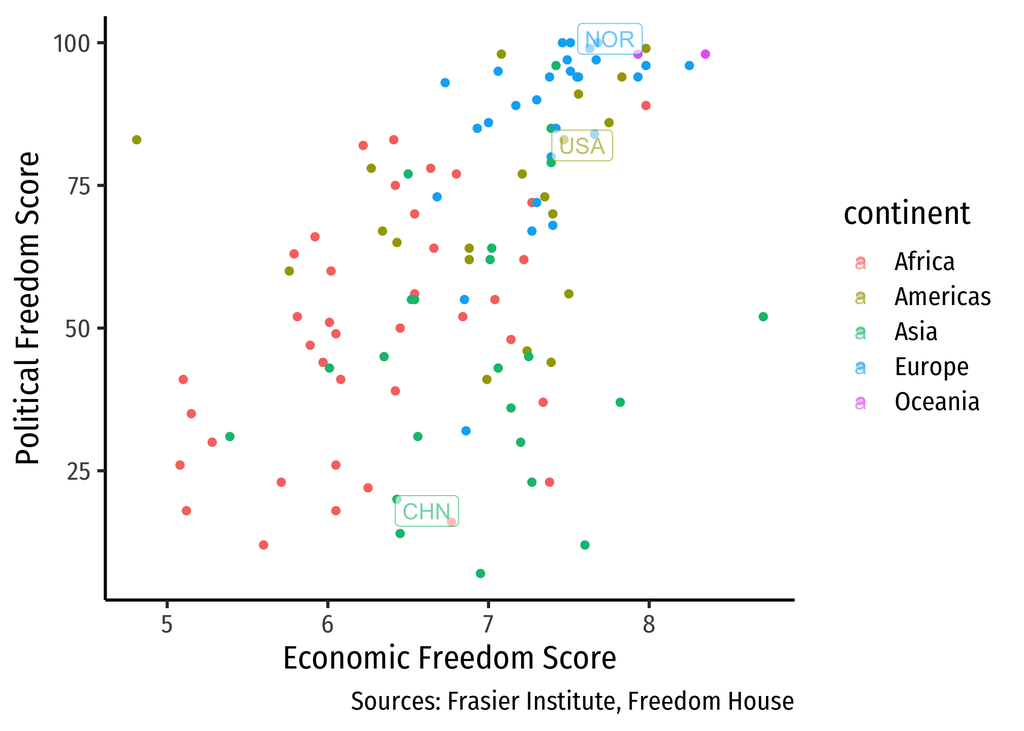

```r
# install.packages("ggrepel")
library(ggrepel)

interest<-filter(freedom, ISO %in% c("CHN", "NOR", "USA"))

ggplot(data=freedom, aes(x=ef,y=Total))+
  geom_point(aes(color=continent))+
  geom_label_repel(data=interest, aes(ef, Total, label=ISO,color=continent),alpha=0.6)+
  xlab("Economic Freedom Score")+ylab("Political Freedom Score")+theme_bw()+labs(caption="Sources: Frasier Institute, Freedom House")+
  theme_classic(base_family = "Fira Sans Condensed", base_size=16)
```

## 13.

**Make another plot similar to 12, except this time use GDP per Capita (`gdp`) as `y`. Feel free to try to put a regression line with `geom_smooth()`!**[^11]. **Those of you in my Development course, you just made my graphs from [Lesson 2](https://devf19.classes.ryansafner.com/slides/02-slides#23)!**

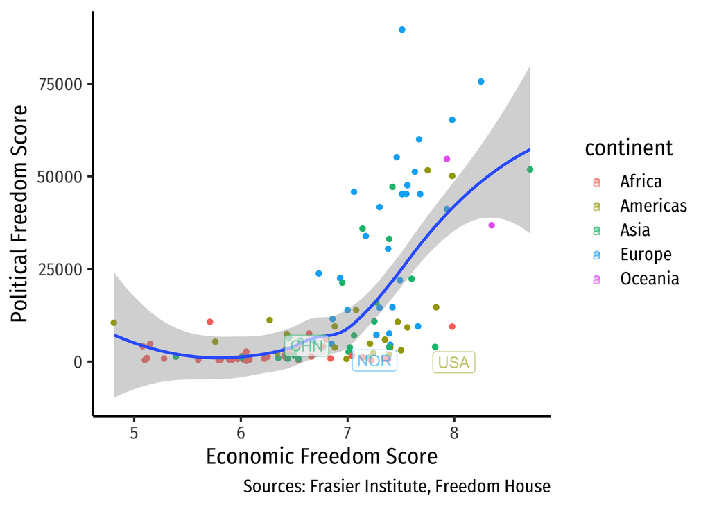

```r
ggplot(data=freedom, aes(x=ef,y=gdp))+
  geom_point(aes(color=continent))+
  geom_smooth(data=freedom)+
  geom_label_repel(data=interest, aes(ef, Total, label=ISO,color=continent),alpha=0.6)+
  xlab("Economic Freedom Score")+ylab("Political Freedom Score")+theme_bw()+labs(caption="Sources: Frasier Institute, Freedom House")+
  theme_classic(base_family = "Fira Sans Condensed", base_size=16)
```

[^1]: Or `percent`, if you made that variable, as I did.
[^2]: If your name isn’t in there :(, pick a random name.
[^3]: Hint: if you do this, you’ll get the number of *rows* (years) there are in the data. You want to add the number of babies in each row (`n`), so inside `count`, add `wt=n` to weight the count by `n`.
[^4]: Hint: once you’ve got all the right conditions, you’ll get a table with a lot of data. You only want to `slice` the `1`st row for each table.
[^5]: This is hard to define. For our purposes, let’s define this as names where between 48 and 52% of the babies with the name are Male.
[^6]: If you want, try downloading them from the websites yourself!
[^7]: Note, if you saved as something else in question 9., use that instead of `polfreedom`!
[^8]: Feel free to `rename` these!
[^9]: This automatically adjusts labels so they don’t cover points on a plot!
[^10]: You might also want to set a low `alpha` level to make sure the labels don’t obscure other points!
[^11]: If you do, be sure to set its data to the full `freedom`, not just your three countries!